# Impacto económico y de salubridad que dejó el Covid-19 a los estudiantes de UTEC

# **Introducción**

La pandemia del Coronavirus fue un asunto que agarró a mucha gente desprevenida, causando entre tantas cosas un impacto en la economía debido a que los trabajos de muchas personas se vieron afectados. Esta investigación tiene como fin medir el impacto del Covid 19 en la economía de los familiares de los estudiantes de UTEC y ver si esto afectó en sus estudios.

## **Relevancia**

Investigar sobre cómo el Covid-19 afectó económicamente a las familias de los estudiantes de UTEC es de suma importancia debido a las implicaciones significativas que esta crisis sanitaria ha tenido en la vida de las personas. Al abordar este tema, vamos a obtener una comprensión profunda de los desafíos económicos a los que se enfrentaron las familias durante la pandemia y cómo estos desafíos afectaron directamente la continuidad de los estudios universitarios de los estudiantes de UTEC. Uno de los objetivos secundarios es conocer el estado en el que las personas se encontraban si contrajeron el Covid-19, ya sea leve, grave o crítico. Esto es esencial para comprender el impacto de la enfermedad en la salud de los estudiantes y sus familias, al identificar la gravedad de los casos de Covid-19, se podrá evaluar mejor la correlación entre el estado de salud y el impacto económico experimentado por las familias. Además, mostrar los gastos económicos invertidos en el tratamiento de los estudiantes UTEC afectados por la Covid-19 proporcionará una visión detallada de la carga financiera que las familias tuvieron que soportar. Esto incluirá no solo los costos médicos directos, como las consultas médicas, los medicamentos y las hospitalizaciones, sino también los gastos adicionales relacionados con la prevención y el control del virus, como los equipos de protección personal y las pruebas de diagnóstico. Los resultados de esta investigación pueden ser para implementar medidas de apoyo efectivas y promover el bienestar académico y económico de los estudiantes de UTEC y sus familias en el contexto post pandémico.

## **Objetivos**

### **Principal**

El objetivo principal del estudio es evaluar como el Covid-19 afectó económicamente a las familias de los estudiantes de la UTEC y mediante los datos recolectados analizar, entender y concluir si este perjudicó los estudios universitarios de estos.

### **Secundarios**

- Conocer el estado en el que la persona se encontraba si le dió Covid-19 (Estado leve, grave o crítico)
- Mostrar gastos económicos invertidos en el tratamiento de los estudiantes UTEC afectados por la COVID-19
- Conocer los tratamientos seguidos por los pacientes afectados por el Covid-19 vinculados a los estudiantes de UTEC

## **Contexto**

-Gastos médicos: En algunos casos, los estudiantes universitarios pueden haber enfrentado gastos médicos adicionales debido a la pandemia. Esto puede incluir pruebas de COVID-19, tratamiento médico, visitas a establecimientos médicos, y entre otros. Estos gastos pueden haber ejercido presión sobre los recursos económicos de los estudiantes y sus familias.

-Impacto en la salud: Los estudiantes universitarios que contrajeron COVID-19 pueden haber experimentado una variedad de síntomas, desde síntomas leves, graves y hasta críticos que requerían hospitalización. La enfermedad en sí misma puede haber causado gripe, fiebre, pérdida gustativa y olfativa, y entre otros.

# **Datos**

## **Proceso de recolección de datos**

Se elaboró un formulario mediante el cual se fueron recolectando los datos necesarios para la investigación. Este formulario se compartió por diferentes grupos de estudio de la UTEC mediante enlaces y también fue respondido mediante QR en la misma universidad. Además, las preguntas del formulario contaban con un rango de respuestas para que a la hora de hacer la limpieza de datos no hayan demasiados datos incongruentes.

## **Población, muestra y muestreo**

### **Población**

La población son los estudiantes de Pre-grado de Universidad de Ingeniería y Tecnología del semestre 2023-1.

### **Muestra**

El tamaño de la muestra son 170 alumnos, lo cual representa una cantidad significativa que nos permitirá trabajar con estos datos.

### **Muestreo**

Esta investigación se realizó con muestreo aleatorio simple.

## **Variables**

**Variables numéricas**

| Variable | Tipo | Restricciones |
| --- | --- | --- |
| Edad | Numérica discreta | Entero positivo [15-60] |
| Ciclo | Numérica discreta | Entero positivo [1-10] |
| Peso | Numérica continua | Número real [40-150] |
| Altura | Numérica continua | Número real [130-200] |
| Familiares_Infectados | Numérica discreta | Entero positivo [0-20] |
| Tiempo_Infección | Numérica discreta | Entero positivo [0-100] |
| Vacunas_Recibidas | Numérica discreta | Entero positivo [0-6] |
| Establecimiento_Veces | Numérica discreta | Entero positivo [0-30] |
| COVID19_Veces | Numérica discreta | Entero positivo [0-10] |
| PruebasDescarte_Veces | Numérica discreta | Entero positivo [0-50] |
| Gasto | Numérica continua | Número positivo mayor a 0 |

**Variables categóricas**

| Variable | Tipo | Restricciones |
| --- | --- | --- |
| Escala | Categórica ordinal | Respuesta obligatoria |
| Distrito | Categórica nominal | Respuesta obligatoria |
| Estado | Categórica ordinal | Respuesta obligatoria |
| Tratamiento | Categórica ordinal | Respuesta obligatoria |
| Sintomas | Categórica nominal | Respuesta obligatoria |
| Vacunas_Recibidas | Categórica nominal | Respuesta obligatoria |
| Variante | Categórica nominal | Respuesta obligatoria |
| Tipo_Prueba | Categórica nominal | Respuesta obligatoria |

## **Limpieza de base de datos**

Primero, hay que cargar el archivo en el que se encuentran nuestros datos para comenzar con la limpieza

```r
DF <- read_csv("Encuesta.csv")
```

Eliminamos las columnas que no nos sirven

```r
DF <- select(DF, -`Marca temporal`)
```

Cambiaremos el nombre de las variables para un trabajo más eficiente

```r
DF %>% rename(Edad = `Ingrese su edad`, Ciclo = `Ingrese su ciclo`, Peso = `Ingrese su peso en kg`, Altura = `Ingrese su altura (En centímetros)`, Escala = `Seleccione su escala` , Distrito = `Elija el distrito donde reside`, Familiares_Infectados = `¿Cuántas personas afectadas de Covid hubo en su familia?`, Tiempo_Infección = `¿Cuánto tiempo duro la infección del Covid-19 en su caso? Tiempo en días.`, Vacunas_Recibidas = `¿Cuántas vacunas recibió para contrarrestar el Covid-19 ?`, Establecimiento_Veces =`Ingrese el número de veces que acudió a un establecimiento médico durante la pandemia (2020-2022)`, COVID19_Veces = `¿Cuántas veces le dio el Covid-19?`, PruebasDescarte_Veces = `¿Cuántas veces durante la pandemia se realizó las pruebas de descarte de Covid-19?`, Estado = `Seleccione cual fue estado de gravedad como paciente de Covid-19`, Gasto = `¿Aproximadamente cuánto se gastó (en soles) en el tratamiento para la persona afectada de Covid 19?`, Tratamiento = `Seleccione el tratamiento seguido`, Sintomas = `Seleccione los síntomas que tuvo`, Vacuna = `Seleccione el tipo de vacunas recibidas`, Variante = `Seleccione que variante del Covid-19 le afecto`, TipoPrueba = `¿Qué tipo de prueba de descarte del Covid-19 se realizo?`) -> DFN
```

Entonces procederemos con la limpieza de datos

```r
table(complete.cases(DFN))
```

```
##
## FALSE  TRUE
##    13   157
```

Podemos observar el total de observaciones, que son 170. De estas 170, hay 157 observaciones completas y 13 incompletas. Procederemos a eliminar los datos faltantes.

```r
DFN = na.omit(DFN)
```

Con esto eliminamos los pocos datos faltantes presentes en el data frame. Ahora verificaremos las variables y eliminaremos los datos no representativos de estas.

**Tiempo de infección**

```r
DFN$Tiempo_Infección[DFN$Tiempo_Infección > 60] <- NA
```

Los datos transformados a NA’s los eliminamos

```r
DFN = na.omit(DFN)
```

Algunas variables cuentan con respuestas de más de una opción, por ello, separaremos en diferentes columnas los datos que tengan más de una opción.

**Tipo de prueba**

Con la función separate crearemos 3 variables nuevas que serán: Molecular, Antígena y Ninguna, las cuales representan las opciones disponibles a marcar.

```r
DFN <- DFN %>% separate(TipoPrueba, c("Molecular","Antigena","Ninguna"), sep = ",")
```

A partir de ahora nos centraremos en convertir los datos marcados en TRUE y FALSE

```r
DFN$Molecular[DFN$Molecular == "Molecular"] <- TRUE
DFN$Antigena[DFN$Molecular == "Antigena"] <- TRUE
DFN$Ninguna[DFN$Molecular == "Ninguna"] <- TRUE
DFN$Antigena[DFN$Antigena == " Antigena"] <- TRUE
DFN$Molecular[DFN$Molecular == "Antigena"] <- FALSE
DFN$Molecular[DFN$Molecular == "Ninguna"] <- FALSE
DFN$Antigena[is.na(DFN$Antigena)] <- FALSE
DFN$Ninguna[is.na(DFN$Ninguna)] <- FALSE
```

Aquí tenemos el resumen de la cantidad de personas que se han hecho la prueba molecular, antígena y las que no se han hecho ninguna de las dos.

```r
DFN %>%
  group_by(Molecular,Antigena,Ninguna) %>%
  tally()
```

```
## # A tibble: 4 x 4
## # Groups:   Molecular, Antigena [4]
##   Molecular Antigena Ninguna     n
##   <chr>     <chr>    <chr>   <int>
## 1 FALSE     FALSE    TRUE        8
## 2 FALSE     TRUE     FALSE      50
## 3 TRUE      FALSE    FALSE      70
## 4 TRUE      TRUE     FALSE      27
```

**Vacunas recibidas**

Con las vacunas tenemos el mismo caso que con el tipo de pruebas, por lo tanto, crearemos 3 nuevas variables que serán: Pfizer, AstraZeneca y Sinopharm, cada TRUE indicará que la opción fue marcada y cada FALSE indicará que la opción **NO** fue marcada.

```r
DFN <- DFN %>% separate(Vacuna, c("Pfizer","AstraZeneca","Sinopharm"), sep = ",")
DFN$Pfizer[DFN$Pfizer == "Pfizer"] <- TRUE
DFN$Sinopharm[DFN$Pfizer == "Sinopharm"] <- TRUE
DFN$Sinopharm[DFN$AstraZeneca == " Sinopharm"] <- TRUE
DFN$Sinopharm[DFN$Sinopharm == " Sinopharm"] <- TRUE
DFN$AstraZeneca[DFN$Pfizer == "AstraZeneca"] <- TRUE
DFN$AstraZeneca[DFN$AstraZeneca == " AstraZeneca"] <- TRUE
DFN$Pfizer[DFN$Pfizer != "TRUE"] <- FALSE
DFN$AstraZeneca[DFN$AstraZeneca != "TRUE"] <- FALSE
DFN$AstraZeneca[is.na(DFN$AstraZeneca)] <- FALSE
DFN$Sinopharm[is.na(DFN$Sinopharm)] <- FALSE
```

Con table podemos ver un resumen de la cantidad de personas que se pusieron las diferentes vacunas.

```r
DFN %>%
  group_by(Pfizer,AstraZeneca,Sinopharm) %>%
  tally()
```

```
## # A tibble: 7 x 4
## # Groups:   Pfizer, AstraZeneca [4]
##   Pfizer AstraZeneca Sinopharm     n
##   <chr>  <chr>       <chr>     <int>
## 1 FALSE  FALSE       TRUE         13
## 2 FALSE  TRUE        FALSE        12
## 3 FALSE  TRUE        TRUE         10
## 4 TRUE   FALSE       FALSE        68
## 5 TRUE   FALSE       TRUE         24
## 6 TRUE   TRUE        FALSE        22
## 7 TRUE   TRUE        TRUE          6
```

Y con esto tendríamos la base de datos limpia

```r
summary(DFN)
```

```
##       Edad           Ciclo             Peso            Altura
##  Min.   :16.00   Min.   : 1.000   Min.   : 35.00   Min.   :150.0
##  1st Qu.:18.00   1st Qu.: 2.000   1st Qu.: 59.50   1st Qu.:165.0
##  Median :19.00   Median : 3.000   Median : 67.00   Median :170.0
##  Mean   :19.14   Mean   : 3.594   Mean   : 67.53   Mean   :170.3
##  3rd Qu.:20.00   3rd Qu.: 4.000   3rd Qu.: 75.00   3rd Qu.:176.0
##  Max.   :24.00   Max.   :10.000   Max.   :104.00   Max.   :192.0
##     Escala            Distrito         Familiares_Infectados Tiempo_Infección
##  Length:155         Length:155         Min.   : 0.000        Min.   : 0.00
##  Class :character   Class :character   1st Qu.: 2.000        1st Qu.: 7.00
##  Mode  :character   Mode  :character   Median : 3.000        Median :13.00
##                                        Mean   : 3.594        Mean   :14.15
##                                        3rd Qu.: 4.000        3rd Qu.:18.00
##                                        Max.   :15.000        Max.   :60.00
##  Vacunas_Recibidas Establecimiento_Veces COVID19_Veces   PruebasDescarte_Veces
##  Min.   :1.000     Min.   :0.000         Min.   :0.000   Min.   : 0.000
##  1st Qu.:3.000     1st Qu.:1.000         1st Qu.:1.000   1st Qu.: 1.000
##  Median :3.000     Median :2.000         Median :1.000   Median : 2.000
##  Mean   :2.968     Mean   :2.671         Mean   :1.555   Mean   : 3.239
##  3rd Qu.:3.000     3rd Qu.:4.000         3rd Qu.:2.000   3rd Qu.: 4.500
##  Max.   :4.000     Max.   :8.000         Max.   :5.000   Max.   :32.000
##     Estado              Gasto       Tratamiento          Sintomas
##  Length:155         Min.   :    0   Length:155         Length:155
##  Class :character   1st Qu.:  100   Class :character   Class :character
##  Mode  :character   Median :  200   Mode  :character   Mode  :character
##                     Mean   : 1069
##                     3rd Qu.:  700
##                     Max.   :15000
##     Pfizer          AstraZeneca         Sinopharm           Variante
##  Length:155         Length:155         Length:155         Length:155
##  Class :character   Class :character   Class :character   Class :character
##  Mode  :character   Mode  :character   Mode  :character   Mode  :character
##
##
##
##   Molecular           Antigena           Ninguna
##  Length:155         Length:155         Length:155
##  Class :character   Class :character   Class :character
##  Mode  :character   Mode  :character   Mode  :character
##
##
##
```

# **Análisis descriptivo**

## **Estado~Tratamiento**

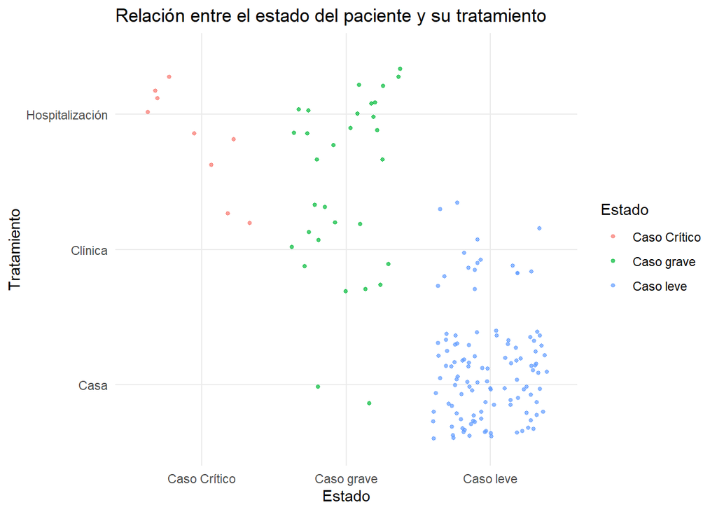

```r
Estado <- DFN$Estado
Tratamiento <- DFN$Tratamiento
ggplot(data = NULL, aes(x = Estado, y = Tratamiento)) +
  geom_jitter(aes(color = Estado), size = 1, alpha = 0.7) +
  xlab('Estado') +
  ylab('Tratamiento') +
  ggtitle('Relación entre el estado del paciente y su tratamiento') +
  theme_minimal()
```

Observamos que para cuando son estados críticos o graves hay una tendencia a preferir la hospitalización, en cambio, para cuando son casos leves se prefiere un tratamiento en la casa. Asimismo, hay una pequeña parte en casos leves que prefieren no ser hospitalizados, o ser llevados a la clínica a fin de ser su tratamiento. Aunque esto nos desvela que los estudiantes UTEC frente al COVID-19 en su mayoría prefieren tomarse cuidados por su cuenta, ya sea en su casa o sin hospitalización, por lo tanto, hay riesgo de que al no seguir un tratamiento médico podría escalar a caso grave o crítico.

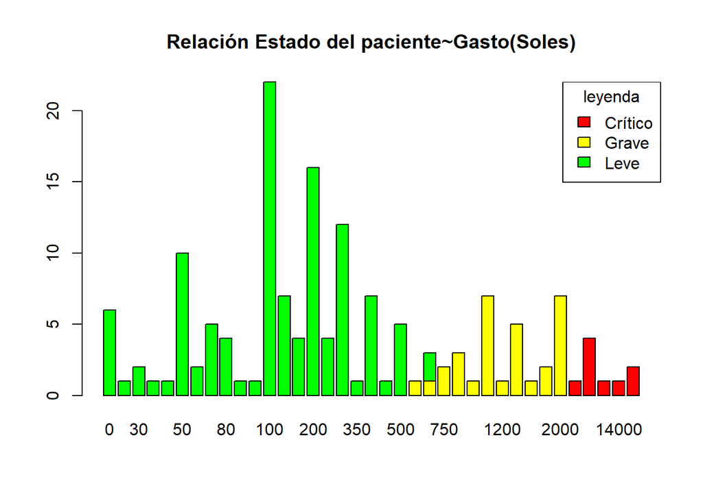

```r
tabgastoyestado<-table(DFN$Estado, DFN$Gasto)
barplot(tabgastoyestado, main="Relación Estado del paciente~Gasto(Soles)",col=c("red","yellow", "green"))

legend(x="topright", legend=c("Crítico","Grave","Leve"),fill = c("red","yellow","green"), title="leyenda")
```

## **Covid Veces~Establecimiento Veces**

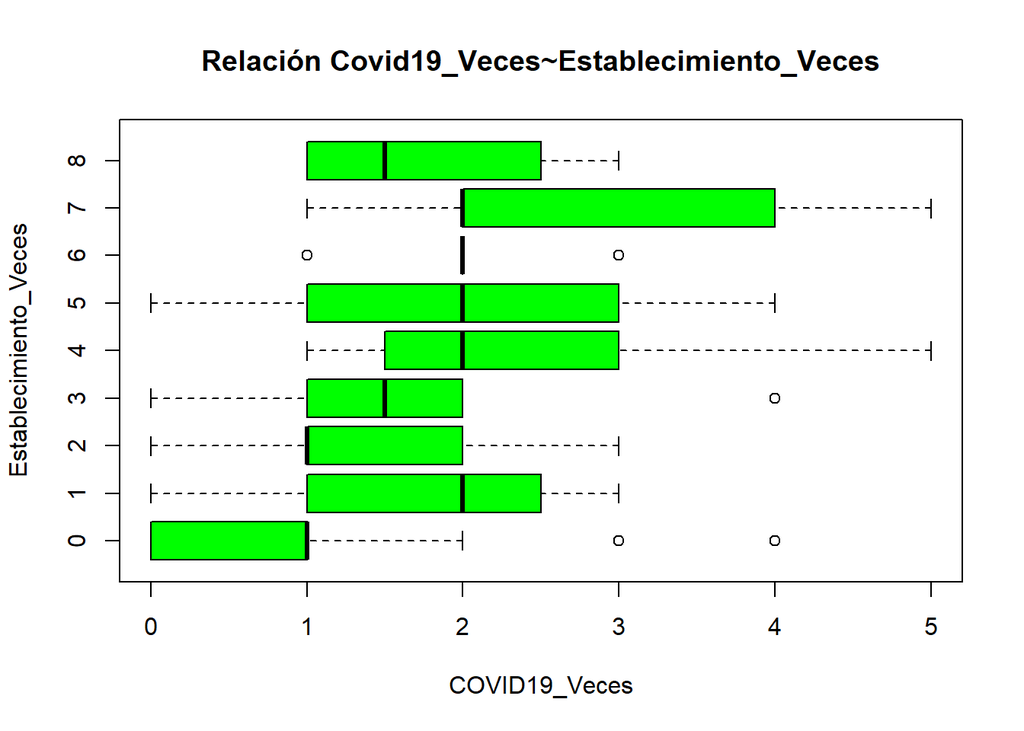

```r
COVID19_Veces <- DFN$COVID19_Veces
Establecimiento_Veces <- DFN$Establecimiento_Veces

tabCyE<-table(COVID19_Veces, Establecimiento_Veces)
boxplot(formula=COVID19_Veces~Establecimiento_Veces, data=DFN,col="green", horizontal= T,main= "Relación Covid19_Veces~Establecimiento_Veces")
```

# **Análisis probabilístico**

## **Probabilidad empírica**

### **Variable: Covid19_Veces**

**Evento: Cantidad de veces que fueron afectados los estudiantes de UTEC por el Covid-19.**

```r
DFN %>%
  group_by(COVID19_Veces) %>%
  tally()
```

```
## # A tibble: 6 x 2
##   COVID19_Veces     n
##           <dbl> <int>
## 1             0    25
## 2             1    59
## 3             2    44
## 4             3    16
## 5             4     9
## 6             5     2
```

```r
tabla <- table(DFN$COVID19_Veces)
ProbTabla <- prop.table(tabla)
ProbTabla
```

```
##
##          0          1          2          3          4          5
## 0.16129032 0.38064516 0.28387097 0.10322581 0.05806452 0.01290323
```

Una vez analizadas las probabilidades empíricas de todos los eventos atómicos de la variable “Covid19_Veces” podemos comprender las situaciones en la que los estudiantes estuvieron implicados. Por ejemplo, la probabilidad de que un estudiante de UTEC haya sido afectado dos veces por el Covid-19 es del 28%. Las probabilidades de estos eventos son importantes para analizar la relación de la afectación económica con respecto a las veces que fueron afectados por el Coronavirus.

### **Variable: Estado**

**Evento: Estado de los estudiantes de UTEC al contraer el Covid19.**

```r
DFN %>%
  group_by(Estado) %>%
  tally()
```

```
## # A tibble: 3 x 2
##   Estado           n
##   <chr>        <int>
## 1 Caso Crítico     9
## 2 Caso grave      31
## 3 Caso leve      115
```

```r
tabla <- table(DFN$Estado)
ProbTabla <- prop.table(tabla)
ProbTabla
```

```
##
## Caso Crítico   Caso grave    Caso leve
##   0.05806452   0.20000000   0.74193548
```

## **Probabilidad condicional**

### **Eventos dependientes**

**Evento A: Seleccionar un alumno que haya tenido Covid19 dos veces o más.**

**Evento B: Seleccionar un alumno con un gasto mayor o igual al promedio.**

```r
A <- DFN$COVID19_Veces
B <- DFN$Gasto
```

```r
#Probabilidad de que un estudiante haya tenido 2 o más veces Covid19
A1 <- filter(DFN,A >= 2)
s <- nrow(A1)
n <- nrow(DFN)
ProbA1 <- round(s/n, 2)
ProbA1
```

```
## [1] 0.46
```

```r
#Probabilidad de que un estudiante haya tenido Covid19 menos de 2 veces
A2 <- filter(DFN,A < 2)
ProbA2 <- round(nrow(A2)/n, 2)
ProbA2
```

```
## [1] 0.54
```

```r
m <- mean(DFN$Gasto)
#Probabilidad de que un estudiante haya tenido un gasto mayor o igual al promedio.
B1 <- filter(DFN,B>=m)
ProbB1 <- round(nrow(B1)/n,2)
ProbB1
```

```
## [1] 0.16
```

```r
#Probabilidad de que un estudiante haya tenido un gasto menor al promedio.
B2 <- filter(DFN,B<m)
ProbB2 <- round(nrow(B2)/n,2)
ProbB2
```

```
## [1] 0.84
```

Para validar la independencia de estos eventos usaremos la siguiente formula:

$$P(A ∩ B) = P(A)P(B)$$

```r
TA <- sum((A>=2)&(B>=m))+sum((A>=2)&(B<m))
TB <- sum((B>=m)&(A>=2))+sum((B>=m)&(A<2))
P1 <- (TA/n)*(TB/n)
P1
```

```
## [1] 0.07388137
```

Asumimos que estos dos eventos son dependientes entre sí, entonces:

$$P(A|B) =P(A ∩ B) /P(B)$$

```r
#Probabilidad condicional
PAB <- P1/ProbB1
PAB
```

```
## [1] 0.4617586
```

### **Eventos independientes**

**Evento A: Seleccionar un alumno con más de 20 años.**

**Evento B: Seleccionar un alumno que estuvo con Covid19 por más de 20 días.**

```r
a <- DFN$Edad
b <- DFN$Tiempo_Infección
```

```r
#Probabilidad de que un estudiante tenga más de 20 años
a1 <- filter(DFN,a > 20)
Proba1 <- round(nrow(a1)/n, 2)
Proba1
```

```
## [1] 0.19
```

```r
#Probabilidad de que un estudiante tenga 20 años o menos
a2 <- filter(DFN,a <= 20)
Proba2 <- round(nrow(a2)/n, 2)
Proba2
```

```
## [1] 0.81
```

```r
#Probabilidad de que un estudiante tenga más de 20 días enfermo
b1 <- filter(DFN,b > 20)
Probb1 <- round(nrow(b1)/n, 2)
Probb1
```

```
## [1] 0.16
```

```r
#Probabilidad de que un estudiante tenga 20 días o menos enfermo
b2 <- filter(DFN,b <= 20)
Probb2 <- round(nrow(b2)/n, 2)
Probb2
```

```
## [1] 0.84
```

Para validar la independencia de estos eventos usaremos la siguiente formula:

$$P(A ∩ B) = P(A)P(B)$$

```r
Ta <- sum((a>20)&(b>20))+sum((a>20)&(b<=20))
Tb <- sum((b>20)&(a>20))+sum((b>20)&(a<=20))
p1 <- (Ta/n)*(Tb/n)
p1
```

```
## [1] 0.03121748
```

Asumimos que estos dos eventos son independientes, por lo tanto:

$$P(B|A) = P(A|B)P(B) / P(A)$$

```r
Pab <- sum((a>20)/n)
Pb <- sum((b>20)/n)
Pa <- Proba1*Probb1 + Proba2*Probb2
Pba <- (Pab*Pb)/Pa
Pba
```

```
## [1] 0.0439188
```

## **Variables Aleatorias discretas**

### **Distribución Binomial para la variable Covid19_Veces**

En la realización de este trabajo se han encuestado a 170 alumnos de UTEC sobre la cantidad de veces que tuvieron Covid19. Anteriormente se ha calculado la probabilidad de que un alumno haya tenido dos veces o más Covid19 (0.46). Se desea saber cual es la probabilidad de que de 50 alumnos encuestados aleatoriamente, 25 hayan tenido dos o más veces Covid19.

**Identificación de parámetros**

El modelo que usará para trabajar será el modelo binomial, ya que podemos hallar la probabilidad del éxito en una cantidad fija.

X: Cantidad de alumnos que han tenido Covid19 dos veces o más en un grupo de 50 alumnos

n: Cantidad fija de intentos (50 alumnos)

X ~ Binom(n=50, p=0.46)

Usando la formula del modelo binomial:
$$p_{\mathbb{X}}(x)=\binom{n}{x}p^x(1-p)^{n-x
}$$

```r
choose(50,25)*((0.46)^25)*((1-0.46)^(50-25))
```

```
## [1] 0.09562541
```

En este caso vemos que la probabilidad de encontrar a 25 alumnos que hayan tenido más de dos veces Covid19 en un grupo de 50 encuestados es del 9.56%. Para comprobar este resultado usaremos una gráfica de la función masa.

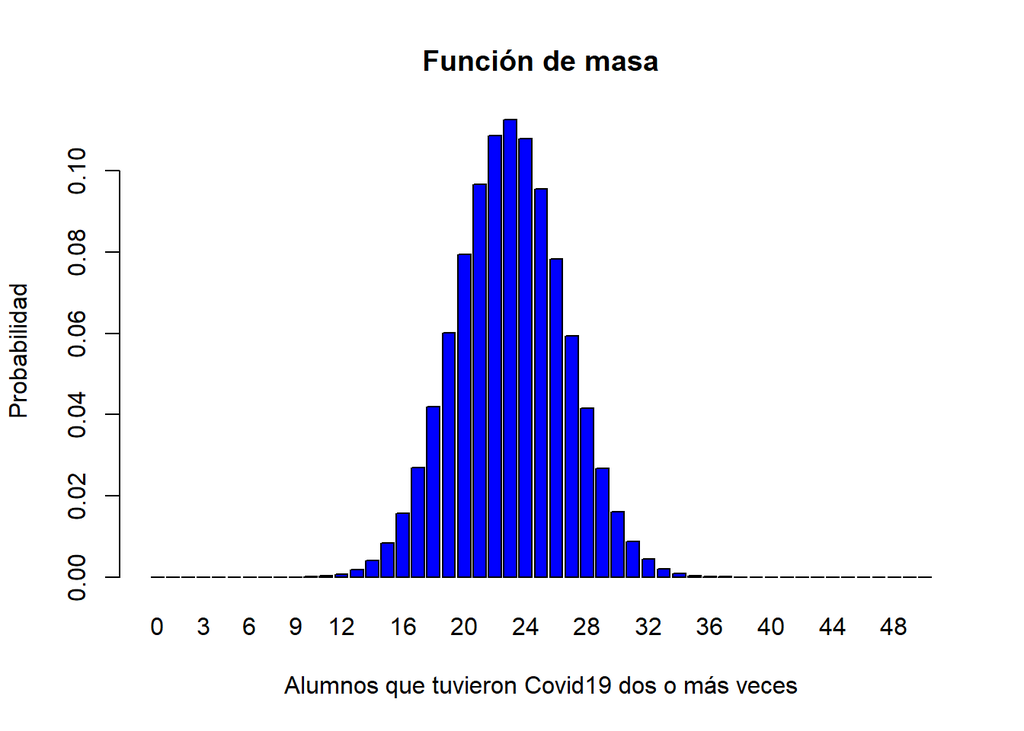

```r
barra<-colores <- c(rep("blue",25))
barplot(dbinom(0:50,size = 50,prob = 0.46),names.arg=c(0:50),main="Función de masa", ylab="Probabilidad", xlab="Alumnos que tuvieron Covid19 dos o más veces",col=barra)
```

Apoyándonos en la gráfica se puede deducir que hay mayor probabilidad de encontrar entre 22 y 24 alumnos que hayan tenido Covid19 dos o más veces en un grupo de 50 alumnos.

### **Distribución binomial para la variable Vacunas_Recibidas**

En este caso, se desea saber cual es la probabilidad de que en un grupo fijo de 100 alumnos 50 de ellos se hayan vacunado dos o menos veces, teniendo en cuenta de que la probabilidad de que un alumno se haya vacunado dos o menos veces es del 17%.

X: Cantidad de alumnos que se han vacunado dos o menos veces en un grupo de 100 alumnos

n: Cantidad fija de intentos (100 alumnos)

X ~Binom(n=100,p=0.17)

```r
choose(100,50)*((0.17)^50)*((1-0.17)^(100-50))
```

```
## [1] 3.021375e-14
```

En el siguiente caso se puede observar que la probabilidad de encontrar a 50 alumnos que se hayan vacunado dos veces o menos en un grupo de 100 encuestados es casi del 0%. Para comprobar este resultado usaremos una gráfica de la función masa.

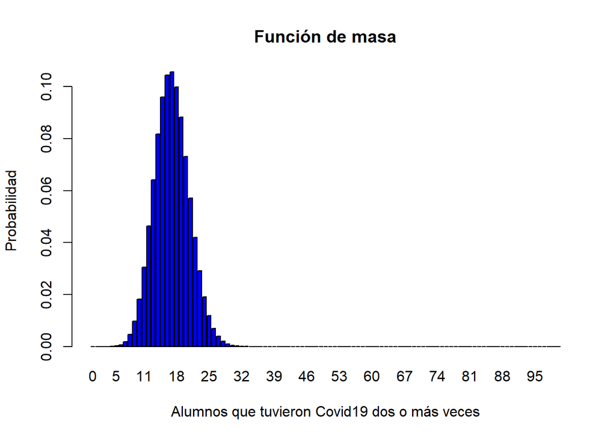

```r
barra<-colores <- c(rep("blue",50))
barplot(dbinom(0:100,size = 100,prob = 0.17),names.arg=c(0:100),main="Función de masa", ylab="Probabilidad", xlab="Alumnos que tuvieron Covid19 dos o más veces",col=barra)
```

## **Variables Aleatorias Continuas**

```r
#Paso 1: Identificar gráficamente una variable aleatoria continua
library(ggplot2)
```

Añadir la curva de normalidad

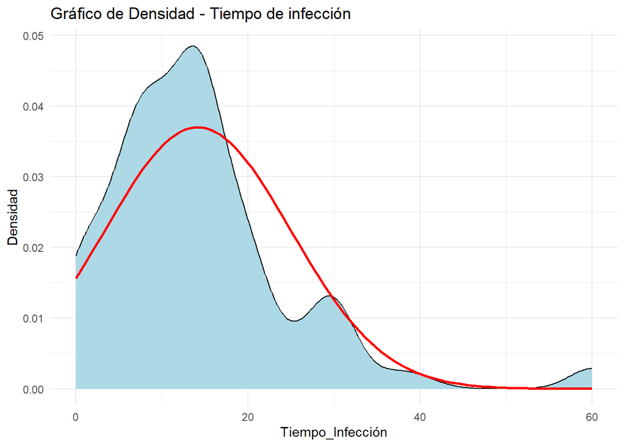

```r
library(readr)
EncuestaLIMPIO <- read_csv("EncuestaLIMPIO.csv",
                           col_types = cols(Edad = col_number(),
                                            Ciclo = col_number(), Peso = col_number(),
                                            Altura = col_number(), Escala = col_character(),
                                            Familiares_Infectados = col_number(),
                                            Tiempo_Infección = col_number(),
                                            Vacunas_Recibidas = col_number(),
                                            Establecimiento_Veces = col_number(),
                                            COVID19_Veces = col_number(), PruebasDescarte_Veces = col_number(),
                                            Molecular = col_logical()))
ggplot(EncuestaLIMPIO, aes(x = Tiempo_Infección)) +
  geom_density(fill = "lightblue", color = "black") +
  labs(x = "Tiempo_Infección", y = "Densidad", title = "Gráfico de Densidad - Tiempo de infección") +
  theme_minimal() +
  stat_function(fun = dnorm, args = list(mean = mean(EncuestaLIMPIO$Tiempo_Infección), sd = sd(EncuestaLIMPIO$Tiempo_Infección)), color = "red", linewidth = 1)
```

[figure not shown]

```r
library(ggplot2)

# Histograma de la variable familiares infectados
ggplot(EncuestaLIMPIO, aes(x = Tiempo_Infección)) +
  geom_histogram(color = "black", fill = "red", bins = 10) +
  labs(x = "Familiares infectados", y = "Frecuencia", title = "Histograma de tiempo de infección") +
  theme_minimal()
```

```r
#Paso 2: Validación de normalidad

#Si se cumple estas condiciones, en tanto tenemos que verificarlo:

#Distribución simétrica:

#Se puede ver que no es tán simétrico como parece, pero podría llegar a ser, sin embargo, ahorita haremos los cálculos.

#Media es aproximadamente a la mediana:
mean(EncuestaLIMPIO$Tiempo_Infección)
```

```
## [1] 14.15484
```

```r
median(EncuestaLIMPIO$Tiempo_Infección)
```

```
## [1] 13
```

```r
# mean = 14.15484
# mediana = 13
```

Observando los valores de la media y la mediana, masomenos no difieren tanto, podrían aproximarse estos valores.

```r
#Varianza es aproximadamente a la desviación estándar al cuadrado
var(EncuestaLIMPIO$Tiempo_Infección)
```

```
## [1] 116.3395
```

```r
(sd(EncuestaLIMPIO$Tiempo_Infección))^2
```

```
## [1] 116.3395
```

```r
# var = 116.3395
# sd^2 = 116.3395
```

```r
probabilidades <- c((table(EncuestaLIMPIO$Tiempo_Infección < 8) / nrow(EncuestaLIMPIO)))
esperanza_T <- mean(EncuestaLIMPIO$Tiempo_Infección, weights = probabilidades)

mean(EncuestaLIMPIO$Tiempo_Infección)
```

```
## [1] 14.15484
```

```r
print(esperanza_T)
```

```
## [1] 14.15484
```

```r
# mean = 14.15484
# esperanza = 14.15484
```

```r
#Paso 3: Parámetros sería la media y la desviación estándar por si se acerca a una distribución normal
# u = media
u <- mean(EncuestaLIMPIO$Tiempo_Infección)
# sigma = desviación estándar
sigma <- sd(EncuestaLIMPIO$Tiempo_Infección)

#X ~ N(u, sigma)
```

```r
#Paso 4: Usar las probabilidades

#Probabilidad de tiempo de infección
# X <- Tiempo de infección
# P(X > 7)

pnorm(7, u, sigma, lower.tail = F)
```

```
## [1] 0.7464436
```

```r
#La probabilidad de que los estudiantes UTEC presenten un tiempo de infección mayor a 7 días es 0.75.
```

#Usando otra variable continua